# 08_analysis

1. Introduction
2. Notebook settings
3. Data Loading, Cleaning and Initial Exploration
4. Data Preparation
5. EDA
6. Statistical Inference and Hypothesis Testing
7. Data Preprocessing
8. Hyperparameter Tuning including Class Weights
9. Ensemble Model with Voting Classifier
10. Cross-validation with Stratified K-Fold
11. Bootstrapping with Bagging
12. Learning Curve Analysis - Ensemble Model (Voting Classifier)
13. Confusion Matrix for the Ensemble Model (Voting Classifier)
14. LIME Interpretation
15. AUC-ROC Curves for the Ensemble Model
16. Final Conclusion
17. Suggested Improvements

## Introduction

According to the World Health Organization (WHO) stroke is the 2nd leading cause of death globally, responsible for approximately 11% of total deaths. This dataset is used to predict whether a patient is likely to get stroke based on the input parameters like gender, age, various diseases, and smoking status. Each row in the data provides relavant information about the patient.

### Dataset Structure

| Column | Description | Datatype | Count |
| --- | --- | --- | --- |
| gender | Gender like: 'Male' 'Female' 'Other' | object | 5110 |
| age | Age | float64 | 5110 |
| hypertension | If someone has hypertension: 0-'No', 1-'Yes' | int64 | 5110 |
| heart_disease | If someone has heart disease: 0-'No', 1-'Yes' | int64 | 5110 |
| ever_married | If someone is married or not: 'Yes' 'No' | object | 5110 |
| work_type | Type of work: 'Private' 'Self-employed' 'Govt_job' 'children' 'Never_worked' | object | 5110 |
| Residence_type | Type of residence: 'Urban' or 'Rural' | object | 5110 |
| avg_glucose_level | Glucose level average | float64 | 5110 |
| bmi | Body Mass Index: estimate the amount of body fat by using height and weight measurements | float64 | 4909 |
| smoking_status | Smoking status;: 'formerly smoked' 'never smoked' 'smokes' 'Unknown' | object | 5110 |

**Target variable:**

| Column | Description | Datatype | Count |
| --- | --- | --- | --- |
| stroke | If someone had stroke or not: 0-'No', 1-'Yes' | int64 | 5110 |

### Notebook settings

```python
from assets.utils.functions import *
```

```python
# Standard libraries

import warnings
import joblib
import numpy as np
import pandas as pd
import matplotlib.pyplot as plt
import seaborn as sns
import matplotlib.patches as mpatches
from IPython.display import display

# Model explanation tools
import lime
import lime.lime_tabular

# Data inspection and EDA
import sidetable as stb
from skimpy import skim


# Statistical analysis and hypothesis testing
from scipy import stats
from scipy.stats import norm, ttest_ind, chi2_contingency, t, zscore
import statsmodels.api as sm
import statsmodels.stats.api as sms_stats
from statsmodels.stats.weightstats import CompareMeans, DescrStatsW
from statsmodels.stats.outliers_influence import variance_inflation_factor

# Machine learning and modeling
from sklearn.model_selection import (train_test_split, cross_val_score,
                                     learning_curve, cross_val_predict,
                                     StratifiedKFold, GridSearchCV,
                                     RandomizedSearchCV)
from sklearn.impute import SimpleImputer
from sklearn.exceptions import DataConversionWarning
from sklearn.pipeline import Pipeline as SkPipeline
from sklearn.compose import ColumnTransformer
from sklearn.preprocessing import (OneHotEncoder, LabelEncoder,
                                   StandardScaler, MinMaxScaler)
from sklearn.ensemble import (RandomForestClassifier,
                              GradientBoostingClassifier,
                              VotingClassifier, BaggingClassifier)
from sklearn.metrics import (classification_report, roc_auc_score,
                             f1_score, make_scorer, accuracy_score,
                             confusion_matrix, ConfusionMatrixDisplay,
                             roc_curve)
from sklearn.inspection import permutation_importance
from sklearn.utils import resample, shuffle
from sklearn.linear_model import LogisticRegression, LogisticRegression
from sklearn.tree import DecisionTreeClassifier
from sklearn.model_selection import RandomizedSearchCV, ShuffleSplit
from xgboost import XGBClassifier
from lightgbm import LGBMClassifier
from catboost import CatBoostClassifier

# Resampling techniques and pipelines (imbalanced data)
from imblearn.pipeline import Pipeline as ImbPipeline
from imblearn.over_sampling import SMOTE

# Additional machine learning libraries
from lightgbm import LGBMClassifier
from xgboost import XGBClassifier
from catboost import CatBoostClassifier

# Categorical encoding
from category_encoders import TargetEncoder

# Warnings
warnings.filterwarnings('ignore')
```

```python
%load_ext pycodestyle_magic
# %reload_ext pycodestyle_magic
%pycodestyle_on
%flake8_on
%flake8_on --max_line_length 79
%matplotlib inline
```

### Data Loading, Cleaning and Initial Exploration

```python
main_df = pd.read_csv("assets/data/healthcare-dataset-stroke-data.csv")
main_df.head()
```

|  | id | gender | age | hypertension | heart_disease | ever_married | work_type | Residence_type | avg_glucose_level | bmi | smoking_status | stroke |
| --- | --- | --- | --- | --- | --- | --- | --- | --- | --- | --- | --- | --- |
| 0 | 9046 | Male | 67.0 | 0 | 1 | Yes | Private | Urban | 228.69 | 36.6 | formerly smoked | 1 |
| 1 | 51676 | Female | 61.0 | 0 | 0 | Yes | Self-employed | Rural | 202.21 | NaN | never smoked | 1 |
| 2 | 31112 | Male | 80.0 | 0 | 1 | Yes | Private | Rural | 105.92 | 32.5 | never smoked | 1 |
| 3 | 60182 | Female | 49.0 | 0 | 0 | Yes | Private | Urban | 171.23 | 34.4 | smokes | 1 |
| 4 | 1665 | Female | 79.0 | 1 | 0 | Yes | Self-employed | Rural | 174.12 | 24.0 | never smoked | 1 |

```python
main_df.stb.freq(['stroke'], cum_cols=False).round(2)
```

|  | stroke | count | percent |
| --- | --- | --- | --- |
| 0 | 0 | 4861 | 95.13 |
| 1 | 1 | 249 | 4.87 |

```python
# Drop column = 'id'
main_df.drop(columns='id', inplace=True)
```

```python
main_df.info()
```

```
<class 'pandas.core.frame.DataFrame'>
RangeIndex: 5110 entries, 0 to 5109
Data columns (total 11 columns):
 #   Column             Non-Null Count  Dtype
---  ------             --------------  -----
 0   gender             5110 non-null   object
 1   age                5110 non-null   float64
 2   hypertension       5110 non-null   int64
 3   heart_disease      5110 non-null   int64
 4   ever_married       5110 non-null   object
 5   work_type          5110 non-null   object
 6   Residence_type     5110 non-null   object
 7   avg_glucose_level  5110 non-null   float64
 8   bmi                4909 non-null   float64
 9   smoking_status     5110 non-null   object
 10  stroke             5110 non-null   int64
dtypes: float64(3), int64(3), object(5)
memory usage: 439.3+ KB
```

```python
skim(main_df)
```

```
╭──────────────────────────────────────────────── skimpy summary ─────────────────────────────────────────────────╮
│          Data Summary                Data Types                                                                 │
│ ┏━━━━━━━━━━━━━━━━━━━┳━━━━━━━━┓ ┏━━━━━━━━━━━━━┳━━━━━━━┓                                                          │
│ ┃ dataframe         ┃ Values ┃ ┃ Column Type ┃ Count ┃                                                          │
│ ┡━━━━━━━━━━━━━━━━━━━╇━━━━━━━━┩ ┡━━━━━━━━━━━━━╇━━━━━━━┩                                                          │
│ │ Number of rows    │ 5110   │ │ string      │ 5     │                                                          │
│ │ Number of columns │ 11     │ │ float64     │ 3     │                                                          │
│ └───────────────────┴────────┘ │ int64       │ 3     │                                                          │
│                                └─────────────┴───────┘                                                          │
│                                                     number                                                      │
│ ┏━━━━━━━━━━━━━━━━━━━━━┳━━━━━━┳━━━━━━━┳━━━━━━━━━━┳━━━━━━━━━┳━━━━━━━━┳━━━━━━━━┳━━━━━━━┳━━━━━━━┳━━━━━━━┳━━━━━━━━┓  │
│ ┃ column_name         ┃ NA   ┃ NA %  ┃ mean     ┃ sd      ┃ p0     ┃ p25    ┃ p50   ┃ p75   ┃ p100  ┃ hist   ┃  │
│ ┡━━━━━━━━━━━━━━━━━━━━━╇━━━━━━╇━━━━━━━╇━━━━━━━━━━╇━━━━━━━━━╇━━━━━━━━╇━━━━━━━━╇━━━━━━━╇━━━━━━━╇━━━━━━━╇━━━━━━━━┩  │
│ │ age                 │    0 │     0 │    43.23 │   22.61 │   0.08 │     25 │    45 │    61 │    82 │ ▅▆▇▇▇▆ │  │
│ │ hypertension        │    0 │     0 │  0.09746 │  0.2966 │      0 │      0 │     0 │     0 │     1 │ ▇    ▁ │  │
│ │ heart_disease       │    0 │     0 │  0.05401 │  0.2261 │      0 │      0 │     0 │     0 │     1 │   ▇    │  │
│ │ avg_glucose_level   │    0 │     0 │    106.1 │   45.28 │  55.12 │  77.25 │ 91.88 │ 114.1 │ 271.7 │ ▇▅▁▁▁  │  │
│ │ bmi                 │  201 │  3.93 │    28.89 │   7.854 │   10.3 │   23.5 │  28.1 │  33.1 │  97.6 │  ▅▇▁   │  │
│ │ stroke              │    0 │     0 │  0.04873 │  0.2153 │      0 │      0 │     0 │     0 │     1 │   ▇    │  │
│ └─────────────────────┴──────┴───────┴──────────┴─────────┴────────┴────────┴───────┴───────┴───────┴────────┘  │
│                                                     string                                                      │
│ ┏━━━━━━━━━━━━━━━━━━━━━━━━━━━━━━━┳━━━━━━━━┳━━━━━━━━━━━━┳━━━━━━━━━━━━━━━━━━━━━━━━━━━━━┳━━━━━━━━━━━━━━━━━━━━━━━━┓  │
│ ┃ column_name                   ┃ NA     ┃ NA %       ┃ words per row               ┃ total words            ┃  │
│ ┡━━━━━━━━━━━━━━━━━━━━━━━━━━━━━━━╇━━━━━━━━╇━━━━━━━━━━━━╇━━━━━━━━━━━━━━━━━━━━━━━━━━━━━╇━━━━━━━━━━━━━━━━━━━━━━━━┩  │
│ │ gender                        │      0 │          0 │                           1 │                   5110 │  │
│ │ ever_married                  │      0 │          0 │                           1 │                   5110 │  │
│ │ work_type                     │      0 │          0 │                           1 │                   5110 │  │
│ │ Residence_type                │      0 │          0 │                           1 │                   5110 │  │
│ │ smoking_status                │      0 │          0 │                         1.5 │                   7887 │  │
│ └───────────────────────────────┴────────┴────────────┴─────────────────────────────┴────────────────────────┘  │
╰────────────────────────────────────────────────────── End ──────────────────────────────────────────────────────╯
```

### Strategy for BMI missing data: Median imputation

I decided to move with the median imputation, since it is quite robust to outliers and represents the central tendency well. Also It won’t distort the central tendency significantly due to the slight skew and is a good general-purpose strategy for small percentages of missing data, which is the case here with 201 missing values.

```python
# Handling missing values in the 'BMI' column by filling with the median value
bmi_median = main_df['bmi'].median()

# Assining values to the BMI missing values
main_df['bmi'] = main_df['bmi'].fillna(bmi_median)

# Check if there are missing values
missing_values = main_df.isnull().sum()
print("Missing values:")
print(missing_values)
```

```
Missing values:
gender               0
age                  0
hypertension         0
heart_disease        0
ever_married         0
work_type            0
Residence_type       0
avg_glucose_level    0
bmi                  0
smoking_status       0
stroke               0
dtype: int64
```

```python
check_blank_or_whitespace(main_df)
```

```
Count of empty strings or single spaces per column:
gender               0
age                  0
hypertension         0
heart_disease        0
ever_married         0
work_type            0
Residence_type       0
avg_glucose_level    0
bmi                  0
smoking_status       0
stroke               0
dtype: int64
```

```python
check_distinct_values(main_df)
```

```
Distinct values for 'gender': ['Male' 'Female' 'Other']
Distinct values for 'ever_married': ['Yes' 'No']
Distinct values for 'work_type': ['Private' 'Self-employed' 'Govt_job' 'children' 'Never_worked']
Distinct values for 'Residence_type': ['Urban' 'Rural']
Distinct values for 'smoking_status': ['formerly smoked' 'never smoked' 'smokes' 'Unknown']
```

### Gender Analysis

```python
main_df['gender'].value_counts()
```

```
gender
Female    2994
Male      2115
Other        1
Name: count, dtype: int64
```

Since there is just one record for gender 'Other', I decided to drop it from the dataset.

```python
main_df.drop(main_df[main_df.gender == 'Other'].index, inplace=True)
main_df.reset_index(drop=True, inplace=True)
```

### Outliers Analysis

Since I want to check I want to visualize them for the features that might present such values. Considering all numerical features, for age, hypertension and hear disease, I won't consider any of them as having outliers, since for age all values seems to be reasonable and for the other two, the values are binary.

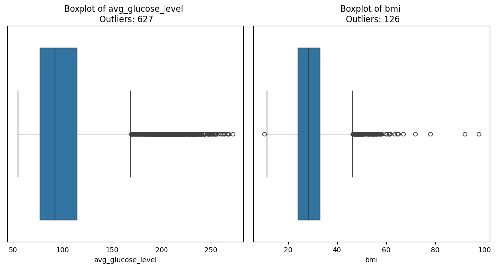

```python
# Assuming 'main_df' contains your dataset and 'numerical_features' is defined
numerical_features = ['avg_glucose_level', 'bmi']


# Function to detect outliers using the IQR method
def count_outliers(feature):
    Q1 = main_df[feature].quantile(0.25)
    Q3 = main_df[feature].quantile(0.75)
    IQR = Q3 - Q1
    lower_bound = Q1 - 1.5 * IQR
    upper_bound = Q3 + 1.5 * IQR
    outliers = main_df[(
        main_df[feature] < lower_bound) | (
            main_df[feature] > upper_bound)]
    return outliers.shape[0]


# Plot outliers for each numerical feature using boxplots
plt.figure(figsize=(15, 10))

# Loop through each feature, create a boxplot, and print outlier count
for i, feature in enumerate(numerical_features, 1):
    # Count the number of outliers
    outliers_count = count_outliers(feature)

    # Create a boxplot
    plt.subplot(2, 3, i)
    sns.boxplot(x=main_df[feature])
    plt.title(f"Boxplot of {feature} \n Outliers: {outliers_count}")

plt.tight_layout()
plt.show()
```

### Winsorizing (Capping) Outliers

For features like BMI and average glucose level, capping outliers is an effective way to handle these extreme values without losing valuable data. By capping, we replace values above or below a certain threshold with the threshold itself, thus reducing the influence of extreme data points. That could improves Model Performance, reduce overfitting, interpretability and balance data distirbution.

```python
# Apply capping for 'avg_glucose_level' and 'bmi'
main_df = cap_outliers(main_df, 'avg_glucose_level')
main_df = cap_outliers(main_df, 'bmi')
```

### Grouping Data

Binning would be useful for further EDA analysis. We can group the data into different bins based on the values of the features. This will help us to understand the data better and also to identify the patterns in the data.

BMI Common Ranges:

1. Underweight: Below 18.5
2. Normal weight: 18.5 - 24.9
3. Overweight: 25.0 - 29.9
4. Obese: 30.0 and above

```python
# Step 1: Define the BMI bins and labels
bmi_bins = [0, 18.5, 24.9, 29.9, float('inf')]
bmi_labels = ['Underweight', 'Normal weight', 'Overweight', 'Obesity']

# Step 2: Create a new column in the dataframe for categorized BMI
main_df['bmi_cat'] = pd.cut(main_df['bmi'], bins=bmi_bins,
                            labels=bmi_labels, right=False)

# Step 3: Calculate the distribution of each BMI category
bmi_dist = main_df['bmi_cat'].value_counts(normalize=True).sort_index()

# Display the distribution of the bmi levels
print(bmi_dist)
```

```
bmi_cat
Underweight      0.065962
Normal weight    0.237816
Overweight       0.315326
Obesity          0.380896
Name: proportion, dtype: float64
```

Common Glucose Level Ranges:

1. Low: Below 70 mg/dL
2. Normal: 70-99 mg/dL
3. Prediabetes: 100-125 mg/dL
4. Diabetes: 126 mg/dL and above

```python
# Step 1: glucose level bins and labels
bins = [0, 70, 99, 125, float('inf')]  # Use 'inf' for an upper bound
labels = ['Low', 'Normal', 'Prediabetes', 'Diabetes']

# Step 2: New column in the dataframe for categorized glucose levels
main_df['avg_glucose_level_cat'] = pd.cut(main_df['avg_glucose_level'],
                                          bins=bins, labels=labels,
                                          right=False)

# Step 3: Distribution of each glucose level category
glucose_dist = main_df['avg_glucose_level_cat'].value_counts().sort_index()

print(glucose_dist)
```

```
avg_glucose_level_cat
Low             754
Normal         2315
Prediabetes    1041
Diabetes        999
Name: count, dtype: int64
```

```python
# Step 1: Define age group bins and labels
age_bins = [0, 2, 12, 18, 35, 60, float('inf')]  # Use 'inf' for an upper bound
age_labels = ['Infant', 'Child', 'Adolescent', 'Young Adults',
              'Middle Aged Adults', 'Old Aged Adults']

# Step 2: Create a new column in the dataframe for categorized age groups
main_df['age_group_cat'] = pd.cut(main_df['age'],
                                  bins=age_bins, labels=age_labels,
                                  right=False)

# Step 3: Calculate the distribution of each age group category
age_group_dist = main_df['age_group_cat'].value_counts().sort_index()

# Display the distribution of the new age groups
print(age_group_dist)
```

```
age_group_cat
Infant                 120
Child                  423
Adolescent             313
Young Adults           988
Middle Aged Adults    1889
Old Aged Adults       1376
Name: count, dtype: int64
```

```python
# Dataframe info and checks
print(main_df.info())
```

```
<class 'pandas.core.frame.DataFrame'>
RangeIndex: 5109 entries, 0 to 5108
Data columns (total 14 columns):
 #   Column                 Non-Null Count  Dtype
---  ------                 --------------  -----
 0   gender                 5109 non-null   object
 1   age                    5109 non-null   float64
 2   hypertension           5109 non-null   int64
 3   heart_disease          5109 non-null   int64
 4   ever_married           5109 non-null   object
 5   work_type              5109 non-null   object
 6   Residence_type         5109 non-null   object
 7   avg_glucose_level      5109 non-null   float64
 8   bmi                    5109 non-null   float64
 9   smoking_status         5109 non-null   object
 10  stroke                 5109 non-null   int64
 11  bmi_cat                5109 non-null   category
 12  avg_glucose_level_cat  5109 non-null   category
 13  age_group_cat          5109 non-null   category
dtypes: category(3), float64(3), int64(3), object(5)
memory usage: 454.8+ KB
None
```

### Univaritate Analysis

The goal of univariate analysis is to explore the data and find patterns in it. We can use different plots to visualize the data and identify the patterns in it.

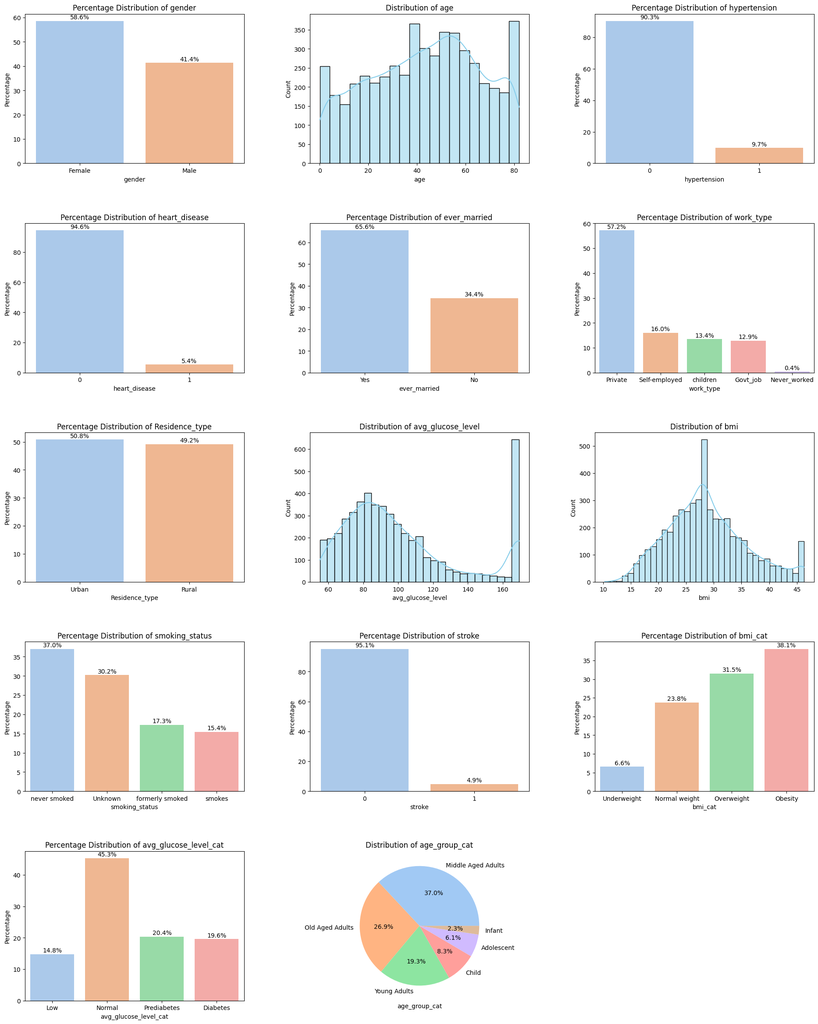

```python
# Drop the 'Id' column before plotting
univariate_analysis(main_df)
```